# Exploring the UNC Breast XevaSet with Xeva

## The model and treatment landscape

Before plotting individual experiments, it helps to understand the overall composition of the dataset.

### Tissue distribution

```r
tissue_summary <- model_df |>
  count(tissue.name, name = "models") |>
  left_join(
    model_df |>
      distinct(tissue.name, patient.id) |>
      count(tissue.name, name = "patients"),
    by = "tissue.name"
  ) |>
  arrange(desc(models))

kable(tissue_summary)
```

| tissue.name | models | patients |
| --- | --- | --- |
| Breast Cancer | 4368 | 148 |

[figure not shown]

```r
ggplot(
  tissue_summary,
  aes(x = reorder(tissue.name, models), y = patients, fill = tissue.name)
) +
  geom_col(show.legend = FALSE) +
  labs(
    title = "Number of model records by disease group",
    x = "Disease group",
    y = "Number of patients"
  ) +
  coord_flip()
```

### Most frequently represented treatments

```r
drug_summary <- model_df |>
  filter(drug != "H2O") |>
  count(drug, name = "models", sort = TRUE) |>
  left_join(
    treatment_df |>
      transmute(
        drug = drug.id,
        drug.label = drugname.standardized,
        `chembl.target_pref_name` = NA_character_
      ),
    by = "drug"
  ) |>
  mutate(
    drug.label = dplyr::coalesce(drug.label, drug),
    `chembl.target_pref_name` = dplyr::coalesce(
      `chembl.target_pref_name`,
      NA_character_
    )
  ) |>
  slice_head(n = 15)

kable(
  drug_summary |>
    select(drug.label, drug, models)
)
```

| drug.label | drug | models |
| --- | --- | --- |
| CFI-400945 | CFI-400945 | 546 |
| PACLITAXEL | PACLITAXEL | 245 |
| CX-5461 | CX-5461 | 213 |
| CFI-402257 | CFI-402257 | 195 |
| BMN-673 | BMN-673 | 185 |
| CARBOPLATIN | CARBOPLATIN | 178 |
| CFI-402257+PACLITAXEL | CFI-402257-3ON4OFF+PACLITAXEL | 121 |
| CDX-011 | CDX-011 | 117 |
| CFI-400945 | CFI-400945-52WEEKLY | 96 |
| CFI-400945 | CFI-400945-5DAILY | 89 |
| ERIBULIN | ERIBULIN-LOW | 86 |
| PACLITAXEL | PACLITAXEL-15DAILY | 70 |
| AZD-8205 | AZD-8205 | 69 |
| ERIBULIN | ERIBULIN | 66 |
| SACITUZAMAB-GOVITECAN | SACITUZAMAB-GOVITECAN | 62 |

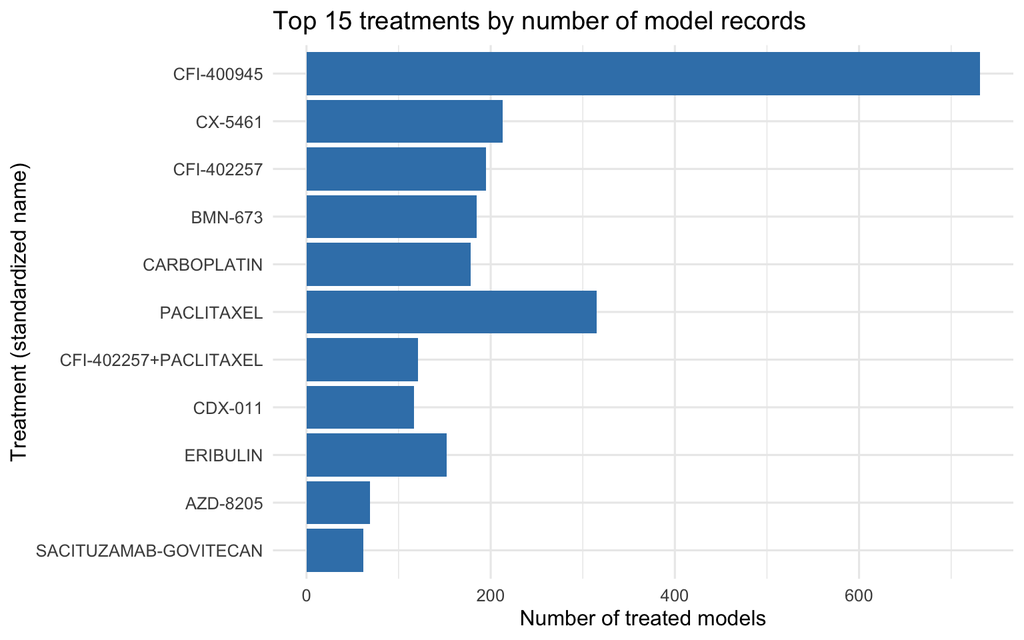

```r
ggplot(drug_summary, aes(x = reorder(drug.label, models), y = models)) +
  geom_col(fill = "#3b82b8") +
  labs(
    title = "Top 15 treatments by number of model records",
    x = "Treatment (standardized name)",
    y = "Number of treated models"
  ) +
  coord_flip()
```

## Looking at individual experiments

```r
sample_batch <- "73230.CFI-400945"
sample_patient <- "73230"
sample_treatment_model <- "73230.CFI-400945.m1"

batch_info <- batchInfo(pdx, batch = sample_batch)[[1]]
batch_tbl <- tibble(
  field = c("Batch", "Control arm", "Treatment arm"),
  value = c(
    batch_info$batch.name,
    paste(batch_info$control, collapse = ", "),
    paste(batch_info$treatment, collapse = ", ")
  )
)

kable(batch_tbl)
```

| field | value |
| --- | --- |
| Batch | 73230.CFI-400945 |
| Control arm | 73230.H2O.m1, 73230.H2O.m10, 73230.H2O.m11, 73230.H2O.m12, 73230.H2O.m13, 73230.H2O.m14, 73230.H2O.m15, 73230.H2O.m16, 73230.H2O.m17, 73230.H2O.m18, 73230.H2O.m19, 73230.H2O.m2, 73230.H2O.m3, 73230.H2… |
| Treatment arm | 73230.CFI-400945.m1, 73230.CFI-400945.m2, 73230.CFI-400945.m3 |

The batch definition shows how `Xeva` pairs an untreated control arm with a treatment arm for the same patient. This is the basic unit used for many downstream response calculations.

```r
experiment_df <- getExperiment(pdx, model.id = sample_treatment_model)
kable(head(experiment_df, 10))
```

| model.id | drug.join.name | time | volume | width | length | dose | date | volume.normal |
| --- | --- | --- | --- | --- | --- | --- | --- | --- |
| 73230.CFI-400945.m1 | CFI-400945 | 0 | 105.97781 | 5.25 | 7.69 | NA | 2017-02-15 | 0.0000000 |
| 73230.CFI-400945.m1 | CFI-400945 | 4 | 70.69047 | 4.58 | 6.74 | NA | 2017-02-19 | -0.3329692 |
| 73230.CFI-400945.m1 | CFI-400945 | 8 | 67.15674 | 4.85 | 5.71 | NA | 2017-02-23 | -0.3663132 |
| 73230.CFI-400945.m1 | CFI-400945 | 12 | 66.40732 | 4.87 | 5.60 | NA | 2017-02-27 | -0.3733847 |
| 73230.CFI-400945.m1 | CFI-400945 | 15 | 55.92233 | 4.62 | 5.24 | NA | 2017-03-02 | -0.4723204 |
| 73230.CFI-400945.m1 | CFI-400945 | 19 | 63.78637 | 4.65 | 5.90 | NA | 2017-03-06 | -0.3981158 |
| 73230.CFI-400945.m1 | CFI-400945 | 22 | 51.05212 | 4.27 | 5.60 | 15 | 2017-03-09 | -0.5182754 |
| 73230.CFI-400945.m1 | CFI-400945 | 29 | 64.88975 | 4.59 | 6.16 | 15 | 2017-03-16 | -0.3877044 |
| 73230.CFI-400945.m1 | CFI-400945 | 37 | 127.84961 | 5.65 | 8.01 | 15 | 2017-03-24 | 0.2063809 |
| 73230.CFI-400945.m1 | CFI-400945 | 43 | 176.56250 | 6.25 | 9.04 | 15 | 2017-03-30 | 0.6660327 |

### Batch-level growth curves

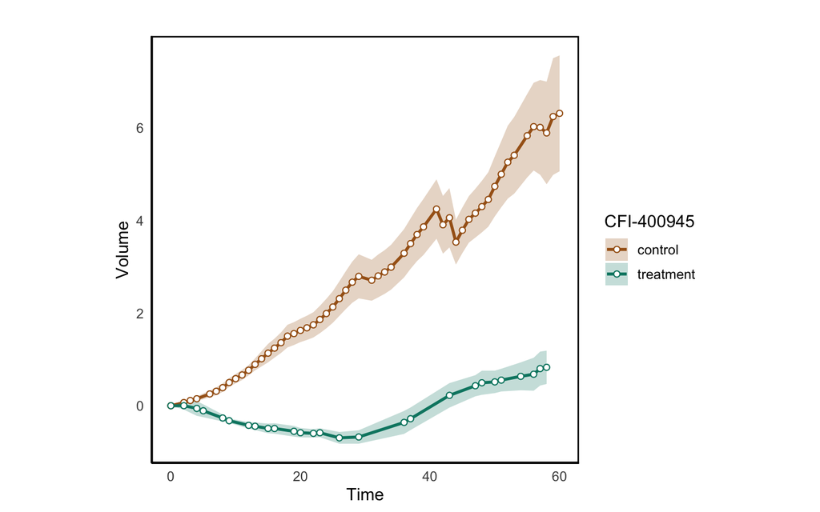

```r
plotPDX(
  pdx,
  batch = sample_batch,
  vol.normal = TRUE,
  max.time = 60,
  control.col = "#a6611a",
  treatment.col = "#018571",
  major.line.size = 1,
  SE.plot='ribbon'
)
```

The normalized plot starts all models on a comparable scale, emphasizing the change in growth between treatment and control. Curves that stay lower indicate slower growth under treatment relative to the untreated arm.

### Patient-level growth curves

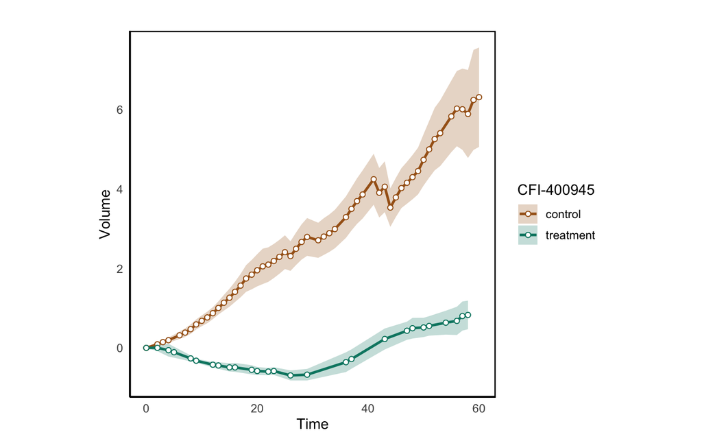

```r
plotPDX(
  pdx,
  patient.id = sample_patient,
  drug = "CFI-400945",
  control.name = "H2O",
  vol.normal = TRUE,
  max.time = 60,
  control.col = "#a6611a",
  treatment.col = "#018571",
  major.line.size = 1,
  SE.plot='ribbon'
)
```

This patient-level call is an alternative for when you have the patient and drug of interest but not the batch name.

## Response measures included in the dataset

The curated object already contains a set of precomputed response summaries. These can be used directly, or recomputed with `summarizeResponse()` and related functions when needed.

### Model-level response summaries

```r
model_metrics <- methods::slot(pdx, "sensitivity")$model

model_metric_summary <- tibble(
  metric = colnames(model_metrics)[-1],
  available_models = colSums(!is.na(model_metrics[-1])),
  pct_models = round(100 * colMeans(!is.na(model_metrics[-1])), 1)
)

kable(model_metric_summary)
```

| metric | available_models | pct_models |
| --- | --- | --- |
| batch.name | 3274 | 100.0 |
| best.response | 3274 | 100.0 |
| best.average.response | 3274 | 100.0 |
| mRECIST | 3274 | 100.0 |
| TGI | 3231 | 98.7 |
| AUC | 3269 | 99.8 |
| slope | 3269 | 99.8 |

### Batch-level response summaries

```r
batch_metrics <- methods::slot(pdx, "sensitivity")$batch

batch_metric_summary <- tibble(
  metric = colnames(batch_metrics)[-1],
  available_batches = colSums(!is.na(batch_metrics[-1])),
  pct_batches = round(100 * colMeans(!is.na(batch_metrics[-1])), 1)
)

kable(batch_metric_summary)
```

| metric | available_batches | pct_batches |
| --- | --- | --- |
| TGI | 1382 | 97.7 |
| abc | 1382 | 97.7 |
| angle | 1382 | 97.7 |
| auc.control | 1383 | 97.7 |
| auc.treatment | 1414 | 99.9 |
| slope.control | 1383 | 97.7 |
| slope.treatment | 1414 | 99.9 |
| BR_median | 1415 | 100.0 |
| BAR_median | 1415 | 100.0 |
| mRECIST | 1415 | 100.0 |
| n_replicates | 1415 | 100.0 |

The response summaries are already broadly populated, and the dataset is ready to use for both descriptive and inferential analyses.

### Distribution of selected response metrics

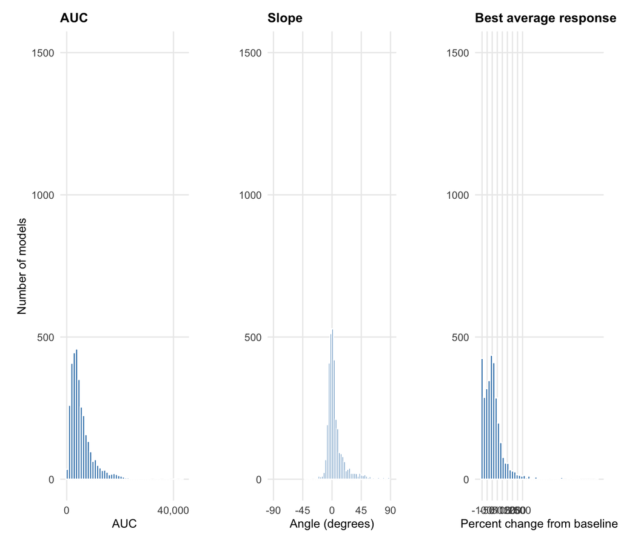

```r
auc_df <- model_metrics |>
  select(AUC) |>
  filter(!is.na(AUC), AUC > 0)

slope_df <- model_metrics |>
  select(slope) |>
  filter(!is.na(slope), between(slope, -90, 90))

bar_df <- model_metrics |>
  select(best.average.response) |>
  filter(!is.na(best.average.response), best.average.response > -100)

base_hist_theme <- theme_minimal(base_size = 12) +
  theme(
    panel.grid.minor = element_blank(),
    plot.title = element_text(face = "bold", size = 12),
    axis.title.x = element_text(size = 11),
    axis.title.y = element_text(size = 11),
    plot.margin = margin(5.5, 10, 5.5, 10)
  )

p_auc <- ggplot(auc_df, aes(x = AUC)) +
  geom_histogram(bins = 50, fill = "#3b82b8", color = "white") +
  coord_cartesian(ylim = c(0, 1500)) +
  scale_x_continuous(
    breaks = seq(0, 140000, by = 40000),
    labels = label_number(accuracy = 1, big.mark = ",")
  ) +
  labs(
    title = "AUC",
    x = "AUC",
    y = "Number of models"
  ) +
  base_hist_theme

p_slope <- ggplot(slope_df, aes(x = slope)) +
  geom_histogram(bins = 50, fill = "#3b82b8", color = "white") +
  coord_cartesian(ylim = c(0, 1500), xlim = c(-90, 90)) +
  scale_x_continuous(
    breaks = seq(-90, 90, by = 45),
    labels = label_number(accuracy = 1)
  ) +
  labs(
    title = "Slope",
    x = "Angle (degrees)",
    y = NULL
  ) +
  base_hist_theme

p_bar <- ggplot(bar_df, aes(x = best.average.response)) +
  geom_histogram(bins = 50, fill = "#3b82b8", color = "white") +
  coord_cartesian(ylim = c(0, 1500)) +
  scale_x_continuous(
    breaks = seq(-100, 300, by = 50),
    labels = label_number(accuracy = 1)
  ) +
  labs(
    title = "Best average response",
    x = "Percent change from baseline",
    y = NULL
  ) +
  base_hist_theme

(p_auc + plot_spacer() + p_slope + plot_spacer() + p_bar) +
  plot_layout(widths = c(1, 0.12, 1, 0.12, 1))
```

Note that these metrics are on different scales and summarize different aspects of response, so they should be interpreted within each panel rather than compared directly across panels.

- `AUC` is the raw area under the tumor volume-versus-time curve, roughly `volume x time`. Higher values indicate greater cumulative tumor burden over the course of the experiment, while lower values indicate slower growth or stronger suppression.
- `best.average.response` is the lowest running average of percent change in tumor volume from baseline. Negative values indicate shrinkage, `-50` means the tumor volume halved, `0` means no net change from baseline, and `100` means the tumor volume doubled.
- `slope` is the angle, in degrees, of the fitted growth line for an individual model. Values near `0` indicate little net growth, positive values indicate growth, negative values indicate shrinkage, and values closer to `90` indicate steeper growth.

## Summarizing response with mRECIST

Below we classify response using mRECIST and display the result as a heatmap across patients and treatments.

```r
brca_mrecist <- summarizeResponse(
  pdx,
  response.measure = "mRECIST",
  group.by = "patient.id",
  tissue = "BRCA"
)

dim(brca_mrecist)
```

```
## [1] 1415    2
```

```r
brca_matrix <- brca_mrecist |>
  as.data.frame() |>
  separate(batch.name, into = c("patient.id", "drug"), sep = "\\.", extra = "merge") |>
  select(patient.id, drug, mRECIST) |>
  pivot_wider(names_from = patient.id, values_from = mRECIST) |>
  as.data.frame()

rownames(brca_matrix) <- brca_matrix$drug
brca_matrix$drug <- NULL

dim(brca_matrix)
```

```
## [1]  67 157
```

```r
# Preview up to 8x8
kable(
  brca_matrix[seq_len(min(8, nrow(brca_matrix))),
    seq_len(min(8, ncol(brca_matrix))),
    drop = FALSE
  ]
)
```

|  | 01-1104 | 100534 | 100672 | 100804 | 104987 | 108045 | 108099 | 16720 |
| --- | --- | --- | --- | --- | --- | --- | --- | --- |
| BMN-673 | PD | CR | NA | NA | PD | NA | SD | SD |
| CARBOPLATIN | PD | PR | PR | NA | PD | PD | SD | PD |
| CDX-011 | PD | SD | SD | SD | NA | SD | SD | SD |
| CFI-400945 | SD | SD | PD | PR | PD | PR | SD | PD |
| CFI-400945-41.6WEEKLY | SD | NA | PD | SD | NA | NA | NA | NA |
| CFI-400945-52WEEKLY | PR | SD | PD | CR | PD | NA | PR | PD |
| CFI-400945-5DAILY | PD | NA | NA | SD | NA | PD | NA | NA |
| CFI-402257 | PD | PD | NA | NA | NA | NA | SD | SD |

The matrix is organized with drugs in rows and patients in columns. Entries such as `CR`, `PR`, `SD`, and `PD` summarize the observed treatment outcome for each patient-drug combination.

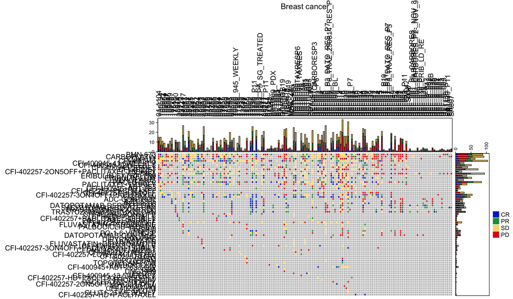

```r
plotmRECIST(
  brca_matrix,
  control.name = "untreated",
  name = "Breast cancer",
  sort = FALSE
)
```

This style of plot is especially helpful for scanning the dataset for drugs with broad activity versus drugs that only benefit specific patient subsets.

## Waterfall plots

```r
waterfall(
  pdx,
  drug = "PACLITAXEL",
  res.measure = "best.average.response"
)
```

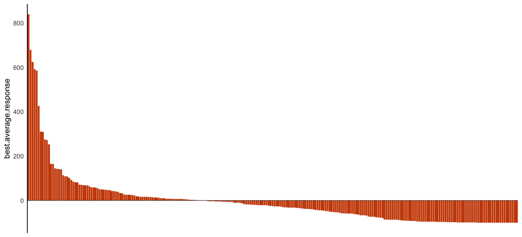

Lower `best.average.response` values correspond to stronger inhibition or shrinkage, while higher values reflect continued growth. This allows us to compare treatment sensitivity across many models at once.

### A publication-style mutation-annotated waterfall

```r
cm_mut <- summarizeMolecularProfiles(
  pdx,
  drug = "PACLITAXEL",
  mDataType = "mutation",
  tissue = "BRCA"
)

tp53_raw <- exprs(cm_mut)["TP53", ]

tp53_status <- ifelse(
  !is.na(tp53_raw) & tp53_raw != "",
  "Mutation",
  "Wild type"
)
names(tp53_status) <- sampleNames(cm_mut)

tp53_bar <- tibble(
  TP53 = factor(tp53_status, levels = c("Wild type", "Mutation")),
  best_average_response = pData(cm_mut)$best.average.response
)

kable(as.data.frame(table(tp53_status)))
```

| tp53_status | Freq |
| --- | --- |
| Mutation | 59 |
| Wild type | 7 |

```r
waterfall(
  pdx,
  drug = "PACLITAXEL",
  res.measure = "best.average.response",
  model.id = names(tp53_status),
  model.type = tp53_status,
  type.color = list(
    "Wild type" = "#00468BFF",
    "Mutation" = "#ED0000FF"
  ),
  legend.name = "TP53",
  title = "PACLITAXEL response in BRCA models, colored by TP53 status",
  yname = "Best average response"
)
```

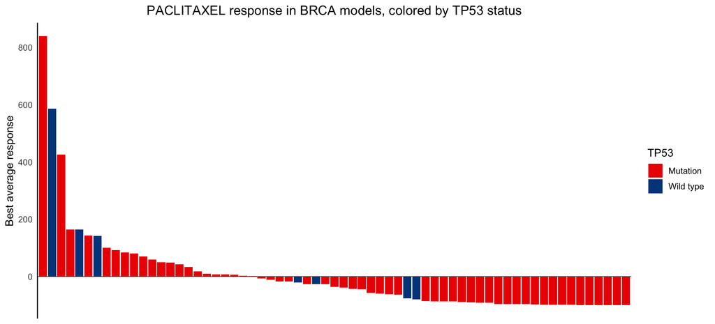

```r
wilcox.test(best_average_response ~ TP53, data = tp53_bar, exact = FALSE)
```

```
##
##  Wilcoxon rank sum test with continuity correction
##
## data:  best_average_response by TP53
## W = 277, p-value = 0.1198
## alternative hypothesis: true location shift is not equal to 0
```

This combination of summary table, waterfall plot, and simple Wilcoxon test is a good first pass at checking whether a molecular annotation tracks with response in a drug-specific subset.

## A small gene-drug association example

The `drugSensitivitySig()` function can be used to associate molecular features with response. For example, the panel below tests expression of ten genes that are plausible candidates for signaling and response biology.

```r
candidate_genes <- c(
  "AKT1", "BRAF", "CDK13", "ERBB2", "ESR1",
  "FGFR2", "MAPKAPK2", "NRAS", "PIK3CA", "TP53"
)

#gene_assoc <- drugSensitivitySig(
#  object = pdx,
#  drug = "PACLITAXEL",
#  mDataType = "RNASeq",
#  features = candidate_genes,
#  sensitivity.measure = "best.average.response",
#  fit = "lm"
#) |>
#  arrange(pvalue)

rna_pax <- summarizeMolecularProfiles(
  pdx,
  drug = "PACLITAXEL",
  mDataType = "RNASeq"
)

gene_expr_matrix <- exprs(rna_pax)[candidate_genes, , drop=FALSE]

responses <- pData(rna_pax)$best.average.response

gene_assoc <- lapply(candidate_genes, function(g) {
  df_temp <- data.frame(
    expression = as.numeric(gene_expr_matrix[g, ]),
    response = responses
  ) |> filter(!is.na(expression), !is.na(response))

  fit <- lm(response ~ expression, data = df_temp)
  s <- summary(fit)

  data.frame(
    feature = g,
    estimate = s$coefficients[2, 1],
    pvalue = s$coefficients[2, 4]
  )
}) |> bind_rows() |> arrange(pvalue)

kable(gene_assoc)
```

| feature | estimate | pvalue |
| --- | --- | --- |
| PIK3CA | -4.2094137 | 0.0005914 |
| ERBB2 | -1.0700965 | 0.0064360 |
| BRAF | -5.0148048 | 0.0234841 |
| AKT1 | -1.1235941 | 0.1100887 |
| CDK13 | -2.6961763 | 0.1257648 |
| MAPKAPK2 | -0.2174377 | 0.2626031 |
| TP53 | -0.4087593 | 0.5441073 |
| NRAS | -0.1301338 | 0.6762473 |
| FGFR2 | -0.1175614 | 0.6926554 |
| ESR1 | -0.1114333 | 0.7837739 |

The `estimate` column gives the direction of association. Because lower `best.average.response` indicates stronger response, a negative estimate suggests that higher expression is associated with greater sensitivity, while a positive estimate suggests the opposite.

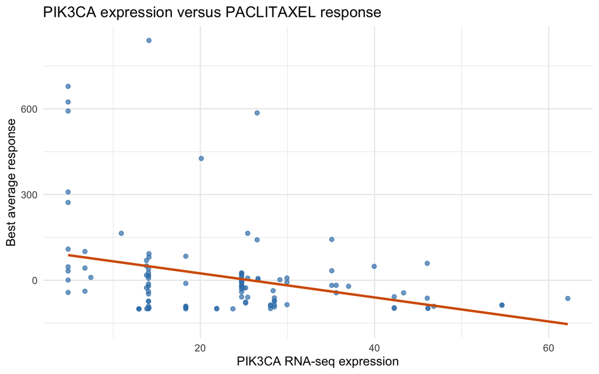

```r
akt1_df <- tibble(
  model_id = sampleNames(rna_pax),
  expression = as.numeric(exprs(rna_pax)["PIK3CA", ]),
  best_average_response = pData(rna_pax)$best.average.response
) |>
  filter(!is.na(expression), !is.na(best_average_response))

ggplot(akt1_df, aes(x = expression, y = best_average_response)) +
  geom_point(alpha = 0.7, color = "#3b82b8") +
  geom_smooth(method = "lm", se = FALSE, color = "#d55e00") +
  labs(
    title = "PIK3CA expression versus PACLITAXEL response",
    x = "PIK3CA RNA-seq expression",
    y = "Best average response"
  )
```

For a real biomarker analysis you would usually expand the feature set, consider tissue stratification, and interpret results using multiple-testing correction. Even so, this example shows how `Xeva` links molecular profiles to treatment response within the same object.